# Bateman Equation - Sensitivity Analysis

## Theory

The Bateman equation is one example where sensitivity analysis can be performed. It is a mathematical model describing abundances and activities in a decay chain as a function of time, based on the decay rates (specific for every type of element) and initial abundances.

The Bateman equation is characterized by the absence of feedbacks, hence making it and the sensitivity analysis easier to perform and assess.

$$\begin{align}
\frac{dN_1(t)}{dt} &= -\lambda_1 N_1(t) \\
\frac{dN_i(t)}{dt} &= -\lambda_i N_i(t) + \lambda_{i-1} N_{i-1}(t)
\\
\frac{dN_k(t)}{dt} &= \lambda_{k-1} N_{k-1}(t)
\end{align}$$

$$N_n(t) = N_1(0) \times \left( \prod_{i=1}^{n-1} \lambda_i \right) \times
\sum_{i=1}^{n} \frac{e^{-\lambda_i t}}{\prod_{\substack{j=1 \\ j \neq
i}}^{n} (\lambda_j - \lambda_i)}$$

## 2. Sensitivity Analysis and Indices

We are interested in the first and total sensitivity indices.

From our generic model:
$$Y = f(X_1, X_2,
\dots, X_k)$$

and the variance decomposition formula:
$$E_Xi (V_{X \sim i}(Y|X_i)) + V_{Xi}(E_{X \sim
i}(Y|X_i)) = V(Y)$$

we derive the first-order sensitivity index:
$$S_i = \frac{V_{Xi}(E_{X \sim
i}(Y|X_i))}{V(Y)}$$

and the total-order sensitivity index:
$$S_{Ti} = 1 - \frac{V(E(Y|X_{\sim i}))}{V(Y)} =
\frac{E(V(Y|X_{\sim i}))}{V(Y)}$$

If a model is additive:
$$\sum_i V_{Xi}
(E_{X \sim i}(Y|X_i)) = V(Y)$$

## Coding

The analyses will be performed with the `sensobol` package by Puy et al.(2022). The two most important R packages, `ggplot2` and `tidyverse`, are also used for data visualization and manipulation. `gridExtra` for plotting multiple graphs in a single plot.

It is always important to choose a random seed, in order to make the results reproducible. The chosen seed number completely arbitrary.

```r
set.seed(100)
```

The user-defined function of the Bateman master equation is defined as follows:

```r
bateman_equation <- function(N0, lambdas, t) {
  n <- length(lambdas)
  result <- 0
  for (i in seq_len(n)) {
    product <- 1
    for (j in seq_len(n)) {
      if (j != i) {
        product <- product * (lambdas[j] - lambdas[i])
      }
    }
    result <- result + exp(-lambdas[i] * t) / product
  }
  return(N0 * prod(lambdas[-n]) * result)
}
```

With $\lambda = (0,35, 0.6, 0.8)$, the Bateman equation is plotted for $t = 100$ and an initial concentration of $N_1(0) = 1$.

```r
lambdas_vector <- c(0.35, 0.6, 0.8)
example_result <- bateman_equation(1, lambdas_vector, 100)
print(example_result)
```

```
[1] 1.176955e-15
```

The output returns the third nuclide concentration in the decay chain at time $t = 100$, given the initial concentration and decay constants. It is virtually equal to 0.

We can also see this with a plot of the Bateman equation for the same parameters.

```r
bateman_plot <- function(N0, lambdas, t) {
  n <- length(lambdas)
  out <- matrix(0, nrow = t, ncol = n)
  for (i in seq_len(t)) {
    for (j in seq_len(n)) {
      out[i, j] <- bateman_equation(N0, lambdas[1:j], i)
    }
  }

  # Convert matrix to dataframe for ggplot
  df <- data.frame(time = rep(seq_len(t), n),
                   value = as.vector(out),
                   series = factor(rep(seq_len(n), each = t)))

  # Plot using ggplot2
  ggplot(df, aes(x = time, y = value, color = series)) +
    geom_line(linewidth = 1) +
    labs(x = 't', y = 'N_k(t)', color = 'Series') +
    theme_minimal()
}
```

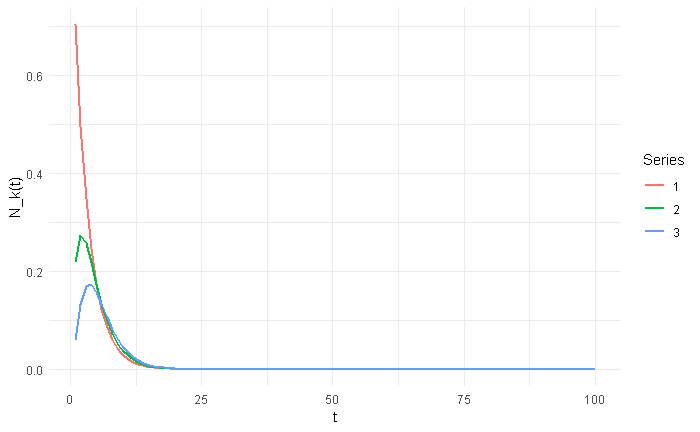

```r
bateman_plot(1, lambdas_vector, 100)
```

```r
model <- function(N0, lambdas, t = 1) {
  n <- length(lambdas)
  out <- numeric(n)  # Initialize a numeric vector to store the results
  for (j in 1:n) {
    out[j] <- bateman_equation(N0, lambdas[1:j], t)
  }
  return(out)
}
```

### Sensitivity Analysis

Now the sensitivity analysis is performed on the Bateman equation. The sensitivity analysis is performed using the Sobol’ method, which is a variance-based method that decomposes the variance of the output into contributions from each input parameter and their interactions.

In particular, the lambdas are sampled from a $\mathcal{U} \sim [0, 1]$.

The SA parameters are defined:

```r
N <- 2^12 # Number of samples
R <- 100
interval <- c(c(0.1, 0.99), c(0.1, 0.99), c(0.1, 0.99)) # Not used
type <- "norm"; conf <- 0.50
nameParams <- paste("λ", 1:length(lambdas), sep = "")
```

The design matrix is created, with each parameter (i.e., the lambdas, sampled from a uniform distribution, see `type = "R"`):

```r
design_matrix <- sobol_matrices(N = N, params = nameParams, type = "R")

round(apply(round(design_matrix, 3), 2, mean), 4)
```

```
    λ1     λ2     λ3
0.4973 0.5020 0.4952
```

The output shows the mean of each lambda, which are close to 0.5, as expected.

Now the Bateman equation is applied to each row, representing each experiment:

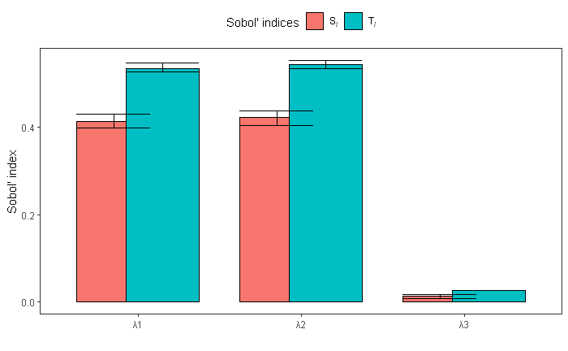

```r
# Initialize a numeric vector to store the results
results_bateman <- numeric(nrow(design_matrix))

# Loop through each row and apply the bateman_equation function
for (x in 1:nrow(design_matrix)) {
  results_bateman[x] <- bateman_equation(1, as.numeric(design_matrix[x, ]), t = 1)
}

ind <- sobol_indices(Y = results_bateman, N = N, params = nameParams, boot = TRUE, R = R, type = type, conf = conf)

plot(ind)
```

The plot shows the indices for each lambda (chain). As expected, the $S_i$ is smaller than the $T_i$, being the total sensitivity index the sum of the first-order and all higher-order indices.

The interval bands around the indices represent the confidence interval, which is set to 0.50 in this case. Try to increase it.

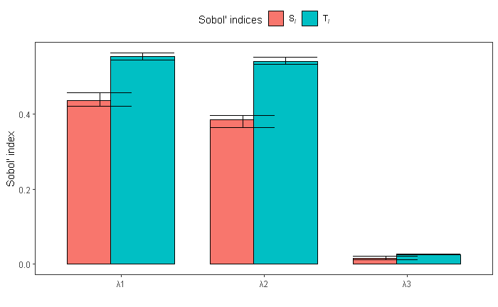

```r
N <- 2^12; R <- 100
interval <- c(c(0.1, 0.99), c(0.1, 0.99), c(0.1, 0.99)) # Not used
type <- "norm"; conf <- 0.50
nameParams <- paste("λ", 1:length(lambdas), sep = "")

design_matrix <- sobol_matrices(N = N, params = nameParams, type = "R")

# Initialize a numeric vector to store the results
results_bateman <- numeric(nrow(design_matrix))

# Loop through each row and apply the bateman_equation function
for (x in 1:nrow(design_matrix)) {
  results_bateman[x] <- bateman_equation(1, as.numeric(design_matrix[x, ]), t = 1)
}

ind <- sobol_indices(Y = results_bateman, N = N, params = nameParams, boot = TRUE, R = R, type = type, conf = conf)

plot(ind)
```

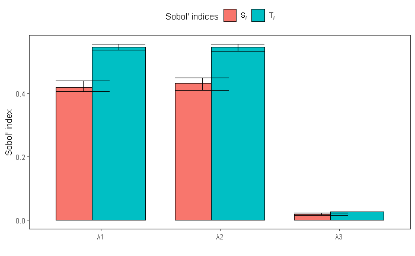

```r
N <- 2^12; R <- 100
interval <- c(c(0.1, 0.99), c(0.1, 0.99), c(0.1, 0.99)) # Not used
type <- "norm"; conf <- 0.50
nameParams <- paste("λ", 1:length(lambdas), sep = "")

design_matrix <- sobol_matrices(N = N, params = nameParams, type = "R")

# Initialize a numeric vector to store the results
results_bateman <- numeric(nrow(design_matrix))

# Loop through each row and apply the bateman_equation function
for (x in 1:nrow(design_matrix)) {
  results_bateman[x] <- bateman_equation(1, as.numeric(design_matrix[x, ]), t = 1)
}

ind <- sobol_indices(Y = results_bateman, N = N, params = nameParams, boot = TRUE, R = R, type = type, conf = conf)

plot(ind)
```